# Exploring Productivity, Sleep, and Study Patterns in University Students

Nina Ross

## Introduction

This project explores relationships between student sleep, study habits, phone usage, and productivity using survey data collected from 3 STATS220 students.

## How Study Location Relates to Productivity

This visualisation explores whether the location students choose to study in may influence their productivity levels. Data was collected from a survey of university students, where participants reported their main study location and the average number of times they picked up their phone during the day. Phone pickups were used as an indicator of distraction levels, with higher phone pickups suggesting lower productivity.

The graph shows that students studying in cafés recorded the highest average number of phone pickups, while students studying at university recorded the lowest average number. Students studying at home and in libraries showed similar levels of phone pickups. These results suggest that quieter or more structured study environments, such as university spaces, may help reduce distractions and improve focus compared with more social environments like cafés.

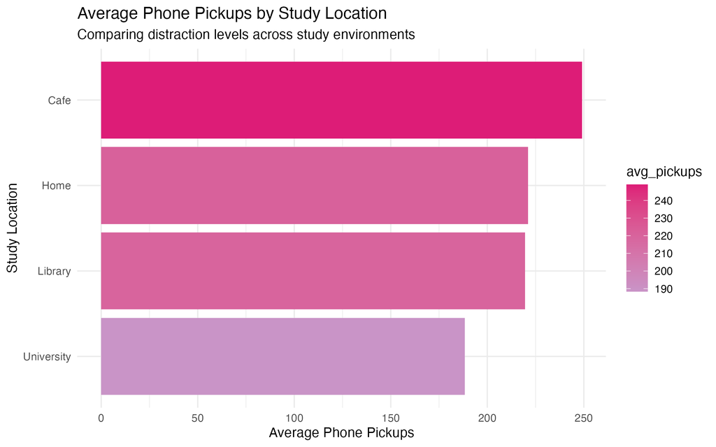

Alternative text: A horizontal bar chart comparing average phone pickups across four study locations: café, home, library, and university. The café category has the highest average phone pickups at around 250 pickups per day. Home and library have similar averages at approximately 220 pickups. University has the lowest average at around 190 pickups. Darker pink colours represent higher phone pickup averages, indicating potentially higher distraction levels.

## Time Spent at University Throughout the Week

This visualisation uses box plots to compare how many hours students spend at university across different days of the week. The data was collected from a survey of university students who reported the number of hours they typically spend at university each day. Box plots are useful for showing the spread and variability of the data, where larger boxes and longer whiskers indicate less consistent results between students.

The graph suggests that students tend to spend more time at university during the middle of the week, particularly on Wednesday and Thursday, where the median university hours are the highest. These days also show greater variability, meaning students reported quite different amounts of time spent on campus. In comparison, Sunday and Monday have lower median university hours and smaller spreads, suggesting more consistent and generally lower attendance at university. The variability across weekdays may reflect differences in class schedules, study habits, and workloads throughout the week.

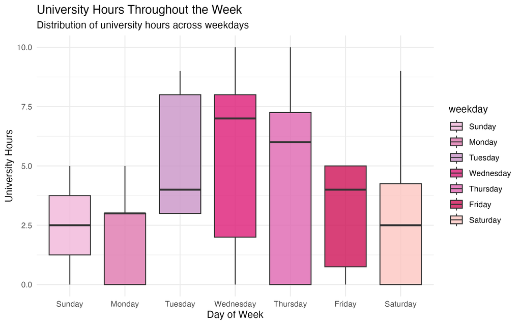

Alternative text: A series of box plots comparing university hours across each day of the week from Sunday to Saturday. Wednesday and Thursday have the highest median university hours, with medians around 6 to 7 hours. These days also have larger boxes and longer whiskers, showing greater variability in student responses. Sunday and Monday have lower median hours, around 2 to 3 hours, with smaller spreads indicating more consistent results. Saturday shows a wide range of hours but a lower median overall. The y-axis ranges from 0 to 10 university hours.

## How sleep influences personal study hours in university students

This visualisation uses a line graph to compare the average number of personal study hours completed by university students across different sleep categories. The data groups students based on the amount of sleep they typically get each night: low sleep (less than 5 hours), medium sleep (5–7 hours), and high sleep (more than 7 hours). Line graphs are useful for showing trends and changes between categories, making it easier to observe how study time varies with sleep duration.

The graph suggests that students who sleep less than 5 hours spend less time on personal study, averaging around 2 study hours. In contrast, students who sleep between 5 and 7 hours show a noticeable increase in study time, averaging approximately 3.6 hours. Students who sleep more than 7 hours also average around 3.6 study hours, indicating that study time remains relatively stable once students achieve at least a moderate amount of sleep. Overall, the visualisation suggests that adequate sleep may be associated with higher levels of personal study among university students.

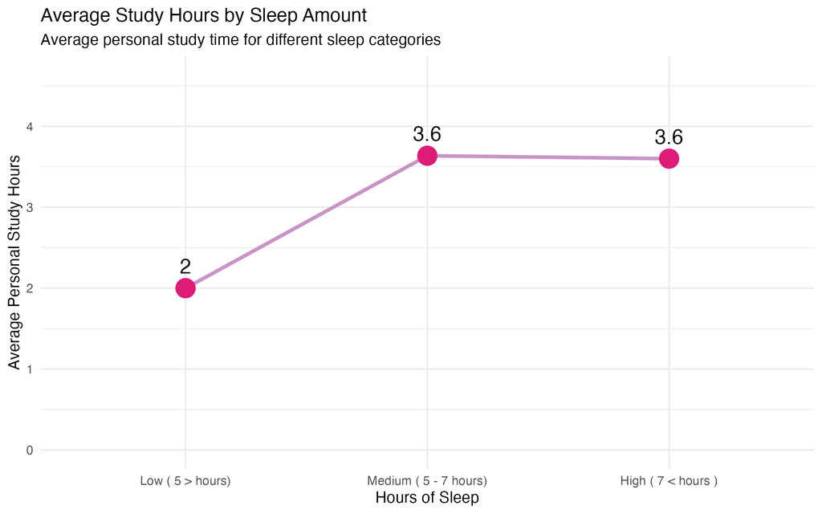

Alternative text: A line graph comparing average personal study hours across three sleep categories: low sleep (less than 5 hours), medium sleep (5–7 hours), and high sleep (more than 7 hours). The low sleep category has the lowest average study time at 2 hours. The medium and high sleep categories both show higher average study times of approximately 3.6 hours. The graph displays an upward trend from low to medium sleep, followed by a stable trend between medium and high sleep categories. The y-axis ranges from 0 to about 5 study hours.